# TUTORIAL 01 - INFORMAÇÕES DE HARDWARE E SOFTWARE

Como obter informações detalhadas de hardware e software em sistemas WINDOWS e LINUX

2022-03-26

## WINDOWS<sup>®</sup> (Vista/7/8/10/11/Server)

Para acesso às informações do sistema incluindo os componentes físicos, aplicações e demais *software* recomendamos a ferramenta *Intel® System Support Utility (ISSU) for Windows*, que permite a geração de um relatório completo das configurações da máquina.

### Baixando e executando o *ISSU*

1. Clique no botão abaixo e **salve** o arquivo *intel-ssu-windows.zip* no computador a ser analisado;

[figure not shown]

Baixar Intel® SSU

2. **Extraia** o arquivo *intel-ssu-windows.zip* para uma pasta de sua preferência*;*
3. **Navegue até a pasta da extração e execute** o arquivo *intel-ssu-windows.exe*. Será aberta a janela do *ISSU*.

> *Caso nesta etapa apareça uma mensagem do sistema “Deseja permitir que este aplicativo faça alterações no seu dispositivo?”, clique em “Sim”.*
4. Na janela inicial do ISSU, marque a caixa de seleção “*Everything*” e depois no botão “*Scan*”.

O *ISSU* realizará a detecção de todos os componentes do computador. Esta etapa pode demorar até 1min.

[figure not shown]

### Visualizando e exportando os resultados para um documento de texto (.*txt*)

5. Após a execução da etapa anterios, a janela do ISSU será atualizada e exibirá um resumo da informações do sistema.

[figure not shown]

6. No menu *dropdown* na parte superior esquerda da janela do *ISSU* estará selecionada a opção **Summary View**; Clicando neste menu haverá outra opção *Detailed View*. Selecione-a para visualizar as configurações completas do computador.

[figure not shown]

7. Para gerar um relatório completo das informações obtidas pelo **ISSU**, clique no botão “**Next>**”, localizado no canto inferir direito da tela.
8. A seguir, clique no botão “**Save**”.

[figure not shown]

9. Será aberta um diálogo padrão do Windows para salvar arquivos. Dê um nome ao arquivo que será salvo e escolha uma pasta de sua preferência. Por último clique em **“Salvar”**. Será gerado e salvo um arquivo de texto (*.txt*) contendo um relatório detalhado das informações da máquina.

## LINUX (distros baseadas em Debian)

> Para acesso às informações do sistema incluindo os componentes físicos, aplicações e demais *software* em distribuições Linux baseadas em Debian, incluso o próprio Debian, Ubuntu, Linux Mint, Pop!OS entre diversos outros, sugerimos a utilização do pacote *lshw* (*list hardware*). Este pacote de fácil utilização e se encontra nos repositórios oficiais do Debian e do Ubuntu. Possui versões também nos repositórios de outros projetos como o Mandriva, RedHat e OpenSUSE. Descreverems a seguir as etapas para instalação e e execução do *lshw* via terminal nas distribuições baseadas em Debian.

### Instalação e execução do pacote o *lshw* pelo terminal:

Abra o terminal e execute:

1. Para atualizar o índice de pacotes:

```bash
sudo apt-get update
```

2. Para instalar o lshw:

```bash
sudo apt-get install lshw
```

3. Para executar o lshw e visualizar as configurações:

```bash
sudo lshw
```

```
 ASUS K55A
    description: Notebook
    product: K55A
    vendor: ASUSTeK COMPUTER INC.
    version: 1.0
    serial: XXXXXXXXXXXXXX
    width: 64 bits
    capabilities: smbios-2.7 dmi-2.7 smp vsyscall32
    configuration: boot=normal chassis=notebook family=K uuid=XXXXXXXXXXXXXXXXX
  *-core
       description: Motherboard
       product: K55A
       vendor: ASUSTeK COMPUTER INC.
       physical id: 0
       version: 1.0
       serial: BSN12345678901234567
       slot: MIDDLE
     *-firmware
          description: BIOS
          vendor: American Megatrends Inc.
          physical id: 0
          version: K55A.204
          date: 03/13/2012
          size: 64KiB
          capacity: 6MiB
          capabilities: pci upgrade shadowing cdboot bootselect socketedrom
          edd int13floppy1200 int13floppy720 int13floppy2880 int5printscreen
          int9keyboard int14serial int17printer acpi usb smartbattery
          biosbootspecification uefi
     *-cache:0
          [...]
     *-cache:1
           [...]
     *-cache:2
         [...]
     *-memory
          [...]
     *-cpu
          [...]
     *-pci
            [...]

        *-usb:0
             [...]

        *-communication
              [...]
              *-logicalvolume:1
              [...]
              *-logicalvolume:2
              [...]
```

### Exportando o relatório no formato *.html* como as configurações da máquina

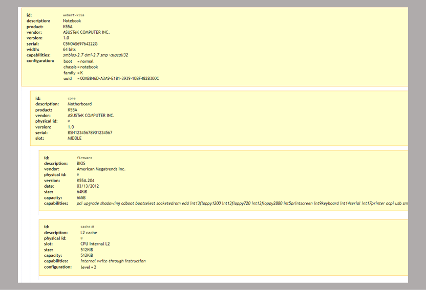

Clique na figura para visualizar a versão completa do relatório completo

```bash
sudo lshw -html > /home/seu-usuario/nome-do-arquivo.html
```

> A exportação no formato *.html* facilita a visualização e extração dos dados de interesse. No entanto é também possível exportação nos formatados de texto simples (*.txt*), XML (.xml) e JSON (.json), bastando substituir os parâmetros -html e a extensão .html

### Instalação e execução do pacote o *lshw* pela interface gráfica:

Uma interface gráfica de usuário (GUI) está disponível para o pacote *lshw* e pode ser instalada e inicializada pelo terminal executando-se:

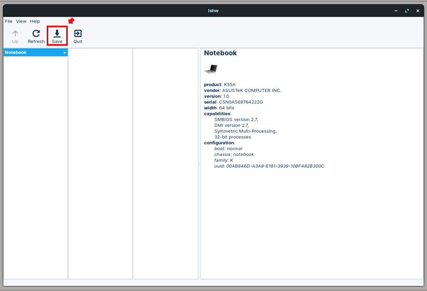

[figure not shown]

```bash
sudo apt-get install lshw-gtk
sudo lshw -X
```

Alternativamente, instalação do pacote *lshw-gtk* pode ser realizada pela central/loja de aplicativos de todas as distribuições atuais Linux basedas em Debian. Após a instalação basta buscar “lshw” no menu de aplicações da distribuição.